# Análisis municipal de la renta

Mario Arteche Miranda y Gonzalo Rodríguez Cañada

# OBJETIVOS DEL TRABAJO

Este grupo de trabajo se plantea la siguiente pregunta: ¿ A traves de ciertas variables, de rango municipal, es posible predecir si la renta de un determinado municipio estrá clasificada como renta baja (grupo 1), renta media (grupo 2) y renta alta (grupo 3)? Para ello se han recogido datos de la pagina web de la Comunidad de Madrid para el año 2014 y creado una variable dummy para determinar con un 1 municipios con renta baja(Municipios Deprimidos, MD), con un 2 municipios con renta media(Municpios Medios, MM) y con un 3 municipios con renta alta (Municipios Ricos, MR). Se utilizaran algoritmos de cross validation para la elección de las variables explicativas y se propondrán diferentes modelos de clasificación y predicción con el fin de encontar aquel con mayor porcentaje de acierto.

# INDICE

1. Presentación y preparación de los datos.
2. Eleccion de las variables explicativas y análisis exploratorio.
3. Regresion logística multinomial.
4. Quadratic Discriminant Analysis (QDA).
5. Random Forest.
6. XGBoost.
7. Conclusiones.
8. Representación gráfica: Leaflet.

## 1. Presentación y limpieza de los datos.

Este dataset es una composición de todas las variables posibles encontradas en la pagina web de la Comunidad de Madrid y que en apartados proximos filtraremos para solo quedarnos con las mas explicativas. Antes de realizar la elección de los regresores se realiza el calculo de los principales estadísticos de las variables numéricas, asi como observar si existen valores NaN entre la muestra. Previamente, para la lectura de los datos, nos saltamos las 2 primeras filas, y limpiamos loa nombres, para dejarlos en un formato “cómodo” para trabajar con ellos.

```
##  [1] "municipio"
##  [2] "producto_interior_bruto_municipal_per_capita_a_euros_1"
##  [3] "estaciones_cercanias_de_tren"
##  [4] "paradas_de_autobus"
##  [5] "bibliotecas_publicas"
##  [6] "farmacias_por_10_000_hab_2"
##  [7] "centros_de_salud_por_10_000_hab_2"
##  [8] "consultorios_locales_por_10_000_hab_2"
##  [9] "comercio_y_hosteleria"
## [10] "transportes_y_almacenamiento"
## [11] "actividades_financieras_y_de_seguros"
## [12] "actividades_inmobiliarias"
## [13] "administracion_publica_educacion_y_sanidad"
## [14] "otras_actividades_de_servicios"
## [15] "declaraciones"
## [16] "renta_del_trabajo_percent"
## [17] "base_imponible_total_por_declaracion"
## [18] "base_imponible_del_ahorro_por_declaracion"
## [19] "resultado_de_la_declaracion_por_declaracion"
```

Seguidamente, observamos como las columnas que aparecen a continuación han de ser eliminadas, ya que arrojan información a posteriori de nuestra predicción, en el caso de no eliminarlas nos estarían sesgando el resultado obtenido. * Renta del trabajo (%) * Base imponible total por declaración * Base imponible del ahorro por declaración * Resultado de la declaración por declaración

Data summary

| Name | DF[, -1] |
| --- | --- |
| Number of rows | 191 |
| Number of columns | 14 |
| _______________________ |  |
| Column type frequency: |  |
| numeric | 14 |
| ________________________ |  |
| Group variables | None |

**Variable type: numeric**

| skim_variable | n_missing | complete_rate | mean | sd | p0 | p25 | p50 | p75 | p100 | hist |
| --- | --- | --- | --- | --- | --- | --- | --- | --- | --- | --- |
| producto_interior_bruto_municipal_per_capita_a_euros_1 | 0 | 1 | 20164.02 | 11117.91 | 9215.00 | 13809.00 | 17012.00 | 21382.00 | 96832.00 | ▇▁▁▁▁ |
| estaciones_cercanias_de_tren | 0 | 1 | 1.40 | 7.62 | 0.00 | 0.00 | 0.00 | 0.00 | 89.00 | ▇▁▁▁▁ |
| paradas_de_autobus | 0 | 1 | 196.26 | 1064.21 | 1.00 | 6.00 | 14.00 | 56.00 | 12495.00 | ▇▁▁▁▁ |
| bibliotecas_publicas | 0 | 1 | 3.05 | 15.14 | 0.00 | 0.00 | 1.00 | 1.00 | 194.00 | ▇▁▁▁▁ |
| farmacias_por_10_000_hab_2 | 0 | 1 | 6.37 | 8.81 | 0.00 | 2.32 | 3.29 | 6.31 | 56.82 | ▇▁▁▁▁ |
| centros_de_salud_por_10_000_hab_2 | 0 | 1 | 0.36 | 0.81 | 0.00 | 0.00 | 0.00 | 0.42 | 5.28 | ▇▁▁▁▁ |
| consultorios_locales_por_10_000_hab_2 | 0 | 1 | 15.98 | 35.30 | 0.00 | 0.00 | 2.23 | 11.41 | 196.08 | ▇▁▁▁▁ |
| comercio_y_hosteleria | 0 | 1 | 64.28 | 40.74 | 10.45 | 36.65 | 52.07 | 85.72 | 222.57 | ▇▅▂▁▁ |
| transportes_y_almacenamiento | 0 | 1 | 14.57 | 15.81 | 0.00 | 5.75 | 10.49 | 18.10 | 108.01 | ▇▁▁▁▁ |
| actividades_financieras_y_de_seguros | 0 | 1 | 7.46 | 10.67 | 0.00 | 3.10 | 5.13 | 8.52 | 95.44 | ▇▁▁▁▁ |
| actividades_inmobiliarias | 0 | 1 | 1.23 | 1.62 | 0.00 | 0.00 | 0.84 | 1.58 | 10.36 | ▇▁▁▁▁ |
| administracion_publica_educacion_y_sanidad | 0 | 1 | 76.15 | 61.37 | 17.03 | 45.47 | 62.28 | 86.25 | 629.03 | ▇▁▁▁▁ |
| otras_actividades_de_servicios | 0 | 1 | 17.46 | 13.01 | 0.00 | 8.95 | 15.24 | 21.24 | 74.63 | ▇▆▁▁▁ |
| declaraciones | 0 | 1 | 48663.38 | 280609.92 | 9.00 | 473.00 | 1909.00 | 7862.00 | 3098235.00 | ▇▁▁▁▁ |

```
## # A tibble: 6 x 15
##   municipio producto_interi~ estaciones_cerc~ paradas_de_auto~ bibliotecas_pub~
##   <chr>                <dbl>            <dbl>            <dbl>            <dbl>
## 1 Sierra S~            16832                3              158                5
## 2 Sierra C~            14792                8              538               17
## 3 Acebeda ~            21514                0                3                0
## 4 Ajalvir              70582                0               18                1
## 5 Alameda ~            15027                0                3                0
## 6 Alamo (E~            12660                0               25                1
## # ... with 10 more variables: farmacias_por_10_000_hab_2 <dbl>,
## #   centros_de_salud_por_10_000_hab_2 <dbl>,
## #   consultorios_locales_por_10_000_hab_2 <dbl>, comercio_y_hosteleria <dbl>,
## #   transportes_y_almacenamiento <dbl>,
## #   actividades_financieras_y_de_seguros <dbl>,
## #   actividades_inmobiliarias <dbl>,
## #   administracion_publica_educacion_y_sanidad <dbl>,
## #   otras_actividades_de_servicios <dbl>, declaraciones <dbl>
```

Posteriormente, eliminamos la variable municipio, ya que no nos aporta ningún valor. Los algorítmos clasificarán y predecirán en función de las características de cada uno de los municipios, no por el nombre.

Tras tener el dataset en la forma que queremos, creamos 3 variables categóricas en función de los tramos de renta que consideramos oportunos para hacer nuestra clasificación.

```
##  [1] "producto_interior_bruto_municipal_per_capita_a_euros_1"
##  [2] "estaciones_cercanias_de_tren"
##  [3] "paradas_de_autobus"
##  [4] "bibliotecas_publicas"
##  [5] "farmacias_por_10_000_hab_2"
##  [6] "centros_de_salud_por_10_000_hab_2"
##  [7] "consultorios_locales_por_10_000_hab_2"
##  [8] "comercio_y_hosteleria"
##  [9] "transportes_y_almacenamiento"
## [10] "actividades_financieras_y_de_seguros"
## [11] "actividades_inmobiliarias"
## [12] "administracion_publica_educacion_y_sanidad"
## [13] "otras_actividades_de_servicios"
## [14] "declaraciones"
## [15] "renta_cat"
```

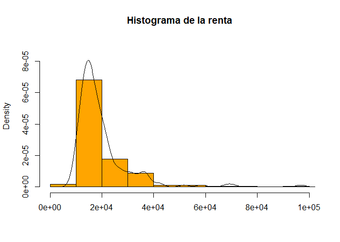

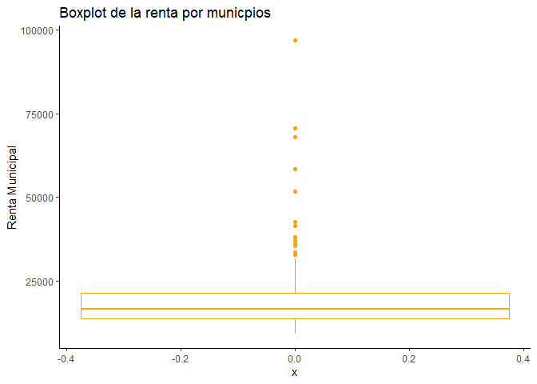

## 2. Eleccion de las variables explicativas y análisis exploratorio.

Para la elección de las variables de nuestros futuros modelos utilizaremos el algoritmo de Best Subset que consiste en estimar todas las regresiones posibles con las combinaciones de los p regresores.

El algoritmo sería considerar el modelo nulo que no presenta ningún regresor y predice segun la media. Con posterioridad, se van añadiendo regresores al modelo y se elige uno en funcion de los criterios de informacion.

|  | Coeficientes |
| --- | --- |
| (Intercept) | 0.3786380 |
| producto_interior_bruto_municipal_per_capita_a_euros_1 | 0.0000412 |
| paradas_de_autobus | 0.0003511 |
| bibliotecas_publicas | -0.0280288 |
| comercio_y_hosteleria | 0.0016752 |
| transportes_y_almacenamiento | 0.0031642 |
| actividades_financieras_y_de_seguros | 0.0065121 |

Para ello tipificamos las variables numéricas, ya que al tratarse de variables en diferentes escalas métricas, podría resultar demasiado complicado extraer conclusiones a partir de ellas.

Dicho lo cual, ploteamos la distribución de la renta de los municipios. Vemos que la distribución en nuestro dataset de trabajo está relativamente desbalanceada, con mayor presencia de barrios “pobres”.

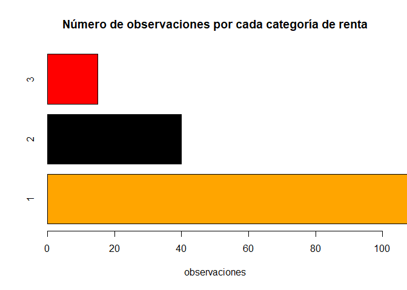

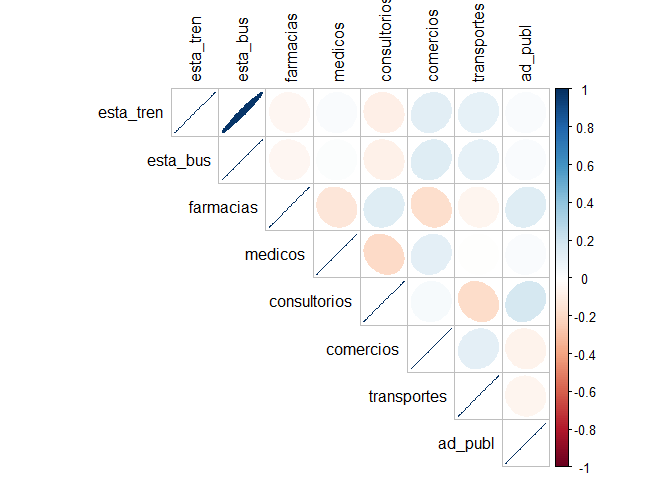

Mostramos en este otro gráfico las distrubuciones de las variables seleccionadas, asi como sus graficos de dispersión, observando de nuevo la poca relación que hay entre dichas variables. Salvo en el caso de estaciones de bus y tren, como es totalmente lógico.

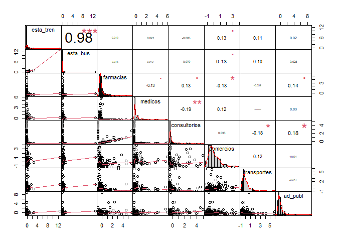

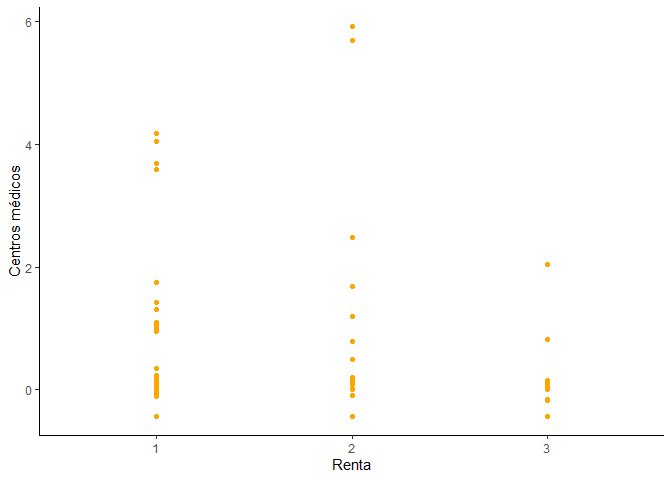

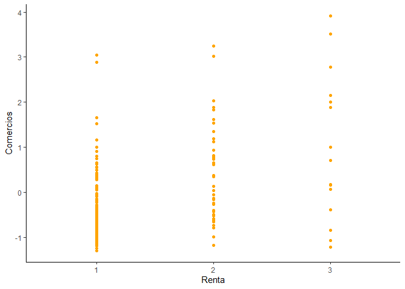

[figure not shown]

[figure not shown]

## 3. Regresion logística.

Antes de la construcción de los diferentes modelos pasamos a dividir nuestra base de datos en dos grupos, train para validar nuestros modelos y test para comprobar como de bien predicen.

El primer modelo que se construirá será la regresión logistica multinomial, un tipo de análisis de regresión utilizado para predecir el resultado de una variable categórica en función de las variables independientes o predictoras. Es útil para modelar la probabilidad de un evento ocurriendo como función de otros factores. En estadística, la regresión logística multinomial generaliza el método de regresión logística para problemas multiclase, es decir, con más de dos posibles resultados discretos. Es decir, se trata de un modelo que se utiliza para predecir las probabilidades de los diferentes resultados posibles de una distribución categórica como variable dependiente, dado un conjunto de variables independientes.

# Regresión Logística Multinomial:

```
## [1] "1" "2" "3"
```

```
## Call:
## multinom(formula = renta ~ ., data = df_train)
##
## Coefficients:
##   (Intercept)  esta_tren    esta_bus  farmacias   medicos consultorios
## 2   -1.616931 -0.7727159 -0.06449587 -0.1043804 0.3237234    0.6391129
## 3   -2.530082 -2.0646017  6.22635879  0.2798647 0.2384826    0.4725920
##   comercios transportes    ad_publ
## 2  1.190600   0.8921440 0.79326740
## 3  1.116804  -0.6651409 0.09877576
##
## Std. Errors:
##   (Intercept) esta_tren esta_bus farmacias   medicos consultorios comercios
## 2   0.3046832  1.398651  2.46681 0.2505027 0.2155954    0.2897431 0.3014146
## 3   0.4537891  1.528217  2.64490 0.2652788 0.3399671    0.4263288 0.3620010
##   transportes   ad_publ
## 2   0.2661347 0.2830701
## 3   0.8517415 0.5745905
##
## Residual Deviance: 166.848
## AIC: 202.848
```

```
##  1  2  3
## 21  5  0
```

```
##
## predicted_class  1  2  3
##               1 15  5  1
##               2  3  1  1
##               3  0  0  0
```

```
##
## predicted_class    1    2    3
##               1 57.7 19.2  3.8
##               2 11.5  3.8  3.8
##               3  0.0  0.0  0.0
```

```
## El acuraccy de la regresión logística multinomial es de  61.5 %
```

```
##
## Call:
## multiclass.roc.default(response = df_test$renta, predictor = y_predmulti,     levels = c(1, 2, 3))
##
## Data: y_predmulti with 3 levels of df_test$renta: 1, 2, 3.
## Multi-class area under the curve: 0.6111
```

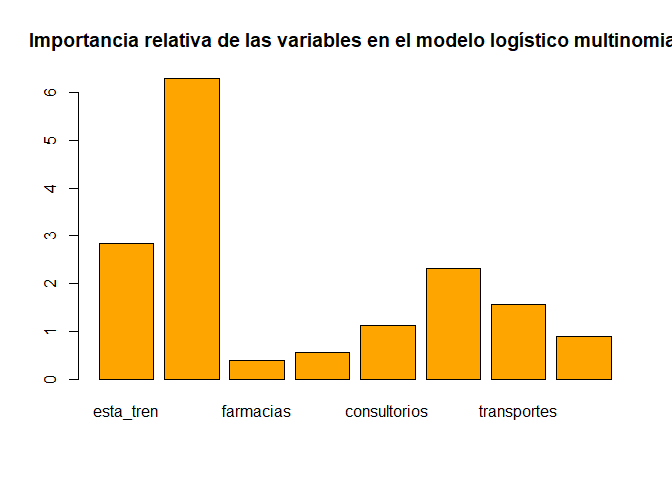

|  | esta_tren | esta_bus | farmacias | medicos | consultorios | comercios | transportes | ad_publ |
| --- | --- | --- | --- | --- | --- | --- | --- | --- |
| Overall | 2.837318 | 6.290855 | 0.3842451 | 0.562206 | 1.111705 | 2.307404 | 1.557285 | 0.8920432 |

# Bondad de ajusto de Mcfadden

```
## fitting null model for pseudo-r2
```

```
##          llh      llhNull           G2     McFadden         r2ML         r2CU
##  -83.4240028 -122.8201211   78.7922366    0.3207627    0.3985050    0.5012602
```

## 5. Modelo discriminante cuadraticos.

Nuestro siguiente modelo es el discriminante cuadrático que es una variante de LDA en la que se estima una matriz de covarianza individual para cada clase de observaciones. QDA es particularmente útil si se sabe previamente que las clases individuales muestran covarianzas distintas. Una desventaja de la QDA es que no puede utilizarse como técnica de reducción de la dimensionalidad.

```
##         Length Class  Mode
## prior     3    -none- numeric
## counts    3    -none- numeric
## means    24    -none- numeric
## scaling 192    -none- numeric
## ldet      3    -none- numeric
## lev       3    -none- character
## N         1    -none- numeric
## call      3    -none- call
## terms     3    terms  call
## xlevels   0    -none- list
```

Calculamos la matriz de confusión y la matriz de confusión para obtener el acuraccy del modelo.

```
##  1  2  3
## 19  5  2
```

```
##              predicciones
## observaciones  1  2  3
##             1 14  4  1
##             2  3  2  0
##             3  1  0  1
```

```
##              predicciones
## observaciones    1    2    3
##             1 53.8 15.4  3.8
##             2 11.5  7.7  0.0
##             3  3.8  0.0  3.8
```

```
## El accuracy de QDA es de  65.4 %
```